# Example 3: Multivariate generalized linear mixed models for continuous bounded outcomes

Henrique A. Laureano, Ricardo R. Petterle and Wagner H. Bonat - LEG/UFPR

# 1 Loading extra packages

```r
library(knitr)
library(TMB)
library(betareg)
library(ggplot2)
library(tidyverse)
library(cowplot)
library(ggcorrplot)
```

# 2 Body fat percentage data set

The motivating example analyzed in this article uses data of the body fat percentage of subjects assisted at the Endocrinology and Metabology Service of the Clinic’s Hospital of the Paraná Federal University, Curitiba, Brazil. The data set contains 298 observations and was previously analyzed by Petterle et al. (2020) by using the multivariate quasi-beta regression model. The data set is composed by two continuous and two categorical covariates, which correspond to: - subject age (in years, ranging from 18 to 87 years), - body mass index (in kg/m$^2$, ranging from 18.5 to 29.9 kg/m$^2$), - gender of subjects (F: female; M: Male) and - level of physical activity practiced routinely (S: sedentary; IA: insufficiently active; A: active). The response variables refer to the body fat percentage (BFP) measured at five regions of the body.

```r
data3 <- read.table("Data_Set.csv", header = TRUE, sep = ",", na.strings = "")
```

```r
tail(data3, n = 10)
```

```
##     AGE  BMI    SEX                  IPAQ  ARMS  LEGS TRUNK ANDROID GYNOID
## 289  79 29.4   Male             Sedentary 0.367 0.444 0.452   0.473  0.479
## 290  80 28.3   Male                Active 0.279 0.353 0.392   0.432  0.407
## 291  80 25.6   Male Insufficiently active 0.229 0.308 0.378   0.437  0.353
## 292  82 28.8 Female             Sedentary 0.471 0.470 0.516   0.548  0.538
## 293  82 22.6 Female             Sedentary 0.361 0.473 0.390   0.408  0.491
## 294  84 29.3   Male Insufficiently active 0.227 0.248 0.405   0.464  0.334
## 295  86 27.2   Male             Sedentary 0.295 0.302 0.416   0.481  0.383
## 296  86 22.6   Male             Sedentary 0.276 0.263 0.370   0.436  0.290
## 297  86 25.6   Male             Sedentary 0.236 0.300 0.392   0.475  0.338
## 298  87 23.4   Male             Sedentary 0.267 0.310 0.373   0.410  0.394
```

# 3 Descriptive analysis

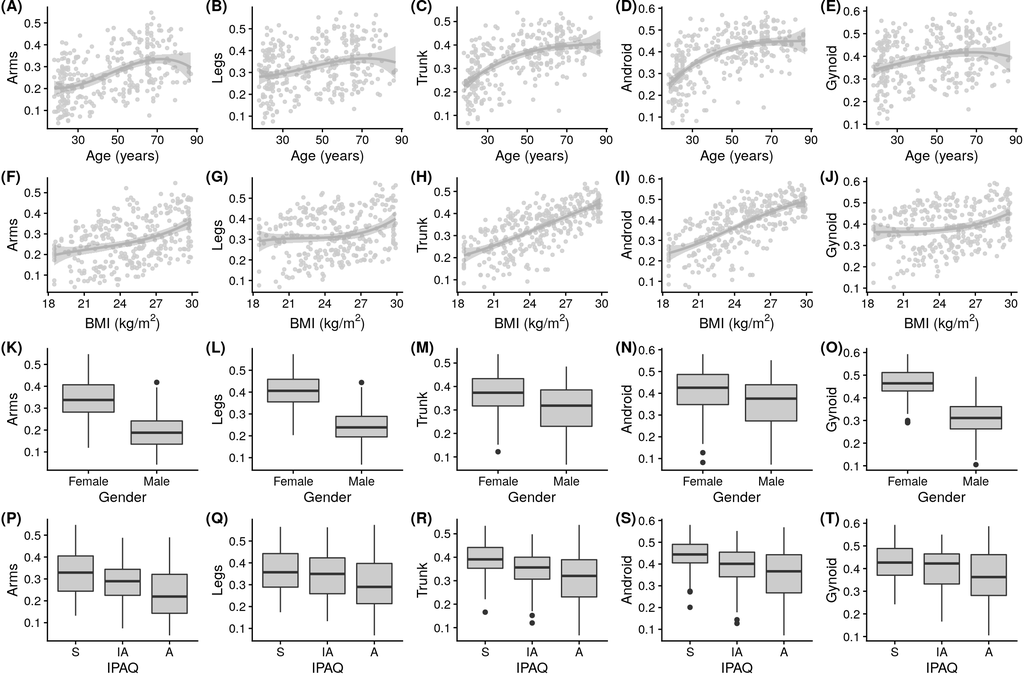

```r
# Preparing
par(mfrow = c(4,5), mar=c(2.8, 2.6, 1.2, 0.5), mgp = c(1.6, 0.6, 0))

# cex (theme_cowplot)
fig_cex = 12


# Age
p1 <- data3 %>%
  ggplot(aes(x = AGE, y = ARMS)) +
  geom_point(size = 1.1, alpha = 0.8, color = "gray80") +
  xlab("Age (years)") +
  ylab("Arms") +
  geom_smooth(method = lm, color = "gray70",
              formula = y ~ splines::bs(x, 3),
              se = T) +
  theme_cowplot(fig_cex)

p2 <- data3 %>%
  ggplot(aes(x = AGE, y = LEGS)) +
  geom_point(size = 1.1, alpha = 0.8, color = "gray80") +
  xlab("Age (years)") +
  ylab("Legs") +
  geom_smooth(method = lm, color = "gray70",
              formula = y ~ splines::bs(x, 3),
              se = T) +
  theme_cowplot(fig_cex)

p3 <- data3 %>%
  ggplot(aes(x = AGE, y = TRUNK)) +
  geom_point(size = 1.1, alpha = 0.8, color = "gray80") +
  xlab("Age (years)") +
  ylab("Trunk") +
  geom_smooth(method = lm, color = "gray70",
              formula = y ~ splines::bs(x, 3),
              se = T) +
  theme_cowplot(fig_cex)

p4 <- data3 %>%
  ggplot(aes(x = AGE, y = ANDROID)) +
  geom_point(size = 1.1, alpha = 0.8, color = "gray80") +
  xlab("Age (years)") +
  ylab("Android") +
  geom_smooth(method = lm, color = "gray70",
              formula = y ~ splines::bs(x, 3),
              se = T) +
  theme_cowplot(fig_cex)

p5 <- data3 %>%
  ggplot(aes(x = AGE, y = GYNOID)) +
  geom_point(size = 1.1, alpha = 0.8, color = "gray80") +
  xlab("Age (years)") +
  ylab("Gynoid") +
  geom_smooth(method = lm, color = "gray70",
              formula = y ~ splines::bs(x, 3),
              se = T) +
  theme_cowplot(fig_cex)

# BMI
p6 <- data3 %>%
  ggplot(aes(x = BMI, y = ARMS)) +
  geom_point(size = 1.1, alpha = 0.8, color = "gray80") +
  xlab(expression(paste("BMI (kg/m"^2,")"))) +
  ylab("Arms") +
  geom_smooth(method = lm, color = "gray70",
              formula = y ~ splines::bs(x, 3),
              se = T) +
  theme_cowplot(fig_cex)

p7 <- data3 %>%
  ggplot(aes(x = BMI, y = LEGS)) +
  geom_point(size = 1.1, alpha = 0.8, color = "gray80") +
  xlab(expression(paste("BMI (kg/m"^2,")"))) +
  ylab("Legs") +
  geom_smooth(method = lm, color = "gray70",
              formula = y ~ splines::bs(x, 3),
              se = T) +
  theme_cowplot(fig_cex)

p8 <- data3 %>%
  ggplot(aes(x = BMI, y = TRUNK)) +
  geom_point(size = 1.1, alpha = 0.8, color = "gray80") +
  xlab(expression(paste("BMI (kg/m"^2,")"))) +
  ylab("Trunk") +
  geom_smooth(method = lm, color = "gray70",
              formula = y ~ splines::bs(x, 3),
              se = T) +
  theme_cowplot(fig_cex)

p9 <- data3 %>%
  ggplot(aes(x = BMI, y = ANDROID)) +
  geom_point(size = 1.1, alpha = 0.8, color = "gray80") +
  xlab(expression(paste("BMI (kg/m"^2,")"))) +
  ylab("Android") +
  geom_smooth(method = lm, color = "gray70",
              formula = y ~ splines::bs(x, 3),
              se = T) +
  theme_cowplot(fig_cex)

p10 <- data3 %>%
  ggplot(aes(x = BMI, y = GYNOID)) +
  geom_point(size = 1.1, alpha = 0.8, color = "gray80") +
  xlab(expression(paste("BMI (kg/m"^2,")"))) +
  ylab("Gynoid") +
  geom_smooth(method = lm, color = "gray70",
              formula = y ~ splines::bs(x, 3),
              se = T) +
  theme_cowplot(fig_cex)

# Gender
p11 <- data3 %>%
  ggplot(aes(x = SEX, y = ARMS)) +
  geom_boxplot(fill = "gray80") +
  xlab("Gender") +
  ylab("Arms") +
  theme_cowplot(fig_cex)

p12 <- data3 %>%
  ggplot(aes(x = SEX, y = LEGS)) +
  geom_boxplot(fill = "gray80") +
  xlab("Gender") +
  ylab("Legs") +
  theme_cowplot(fig_cex)

p13 <- data3 %>%
  ggplot(aes(x = SEX, y = TRUNK)) +
  geom_boxplot(fill = "gray80") +
  xlab("Gender") +
  ylab("Trunk") +
  theme_cowplot(fig_cex)

p14 <- data3 %>%
  ggplot(aes(x = SEX, y = ANDROID)) +
  geom_boxplot(fill = "gray80") +
  xlab("Gender") +
  ylab("Android") +
  theme_cowplot(fig_cex)

p15 <- data3 %>%
  ggplot(aes(x = SEX, y = GYNOID)) +
  geom_boxplot(fill = "gray80") +
  xlab("Gender") +
  ylab("Gynoid") +
  theme_cowplot(fig_cex)

# IPAQ
data3$IPAQ <- factor(data3$IPAQ)
levels(data3$IPAQ) <- c("S", "IA", "A")

p16 <- data3 %>%
  ggplot(aes(x = IPAQ, y = ARMS)) +
  geom_boxplot(fill = "gray80") +
  xlab("IPAQ") +
  ylab("Arms") +
  theme_cowplot(fig_cex)

p17 <- data3 %>%
  ggplot(aes(x = IPAQ, y = LEGS)) +
  geom_boxplot(fill = "gray80") +
  xlab("IPAQ") +
  ylab("Legs") +
  theme_cowplot(fig_cex)

p18 <- data3 %>%
  ggplot(aes(x = IPAQ, y = TRUNK)) +
  geom_boxplot(fill = "gray80") +
  xlab("IPAQ") +
  ylab("Trunk") +
  theme_cowplot(fig_cex)

p19 <- data3 %>%
  ggplot(aes(x = IPAQ, y = ANDROID)) +
  geom_boxplot(fill = "gray80") +
  xlab("IPAQ") +
  ylab("Android") +
  theme_cowplot(fig_cex)

p20 <- data3 %>%
  ggplot(aes(x = IPAQ, y = GYNOID)) +
  geom_boxplot(fill = "gray80") +
  xlab("IPAQ") +
  ylab("Gynoid") +
  theme_cowplot(fig_cex)

# Figure
plot_grid(p1, p2, p3, p4, p5,
          p6, p7, p8, p9, p10,
          p11, p12, p13, p14, p15,
          p16, p17, p18, p19, p20,
          label_size = 13,
          labels = c("(A)", "(B)", "(C)", "(D)", "(E)",
                     "(F)", "(G)", "(H)", "(I)", "(J)",
                     "(K)", "(L)", "(M)", "(N)", "(O)",
                     "(P)", "(Q)", "(R)", "(S)", "(T)"),
          hjust = -0.05, vjust = 1,
          ncol = 5, nrow = 4)
```

# 4 Multivariate generalized linear mixed model

## 4.1 Beta distribution

Let $Y_1, \ldots, Y_n$ be independent random variables with probability density function given by
$$f(y;\mu,\phi) = \dfrac{\Gamma(\phi)}{\Gamma(\mu \phi) \Gamma[(1 - \mu)\phi]} y^{\mu \phi - 1} (1 - y)^{(1 - \mu) \phi - 1},$$
where $y, \mu \in (0,1)$ and $\phi > 0$ denote the precision parameter. According to Ferrari and Cribari-Neto (2004) the expectation and variance of the beta distribution are given, respectively, by

$$\begin{equation}
\label{betamoments}
\mathrm{E}(Y) = \mu \quad~\mathrm{and}~\quad \mathrm{Var}(Y) = \dfrac{\mu(1-\mu)}{1 + \phi}.
\end{equation}$$

## 4.2 Model specification

Let $\mathbf{Y}$ be a response variable matrix $N \times R$, where rows $i = 1, \ldots, N$ are independent subjects and columns $r = 1, \ldots, R$ refers to the $R$ response variables. Let $y_{ir} \in (0,1)$ be the observed value of a random variable $Y_{ir}$, and let $\mathbf{u}_i = (u_{i1}, \ldots, u_{iR})$ be the vector of random intercepts for the subject $i$. For specification of the MGLMM, consider the following hierarchical structure
$$\begin{align} \nonumber
\label{eq:dist}
Y_{ir} | u_{ir} & \sim \mathcal{B}(\mu_{ir}, \phi_{r}), \nonumber \\
g_r(\mu_{ir}) & = \mathbf{x}_{ir}^{\top}\boldsymbol{\beta}_r + u_{ir},
\end{align}$$
where $\phi_{r}$ is assumed to be constant for the $r^{th}$ response variable. The function $g(\cdot)$ is a suitable link function for binary data. In this notation, $\mathbf{x}_{ir}$ and $\boldsymbol{\beta}_r$ are $Q_r \times 1$ vectors of known covariates and unknown regression coefficients associated to the expectation of the $r^{th}$ response variable for the $i^{th}$ subject. Note that, the index $r$ was introduced to ensure different set of covariates for each response variable. Moreover, we assume that the random intercepts follow a multivariate Gaussian distribution, $u_{ir} \sim \mathcal{MVN}_r(\mathbf{0}, \boldsymbol{\Sigma})$, where $\boldsymbol{\Sigma}$ is the $R \times R$ unstructured covariance matrix. Thus, the random intercepts distribution is given by
$$\begin{equation}
\label{eq:gaussmult}
\begin{pmatrix}
u_{i1} \\
\vdots \\
u_{iR} \\
\end{pmatrix} \sim \mathcal{MVN}_R \left[ \begin{pmatrix}
0 \\
\vdots \\
0 \\
\end{pmatrix}, \mathop{\boldsymbol{\Sigma}}_{R \times R} = \begin{pmatrix}
\sigma_1^2 \hspace{-0.2cm} & \hspace{-0.2cm} \ldots \hspace{-0.2cm} & \hspace{-0.2cm}~\rho_{1R} \sigma_1 \sigma_R \\
\vdots \hspace{-0.1cm} & \hspace{-0.2cm} \ddots \hspace{-0.2cm} & \hspace{-0.2cm} \vdots \\
\rho_{1R} \sigma_1 \sigma_R \hspace{-0.1cm} & \hspace{-0.1cm} \ldots \hspace{-0.2cm} & \hspace{-0.2cm} \sigma_R^2 \\
\end{pmatrix}
\right],
\end{equation}$$
where $\rho_{RR'} \in [-1, 1]$ and $\sigma_R^2 > 0$, for $r, r' = 1,, \ldots, R$, are the correlation and variance of the random intercepts, respectively. We highlight that, in our implementation the covariance matrix of the multivariate Gaussian distribution is specified as follows
$$\begin{equation}
\label{eq:covTMB}
\boldsymbol{\Sigma} = \mathrm{diag}(\sigma_1, \ldots, \sigma_R) \boldsymbol{\Sigma}_{\rho} \mathrm{diag}(\sigma_1, \ldots, \sigma_R),
\end{equation}$$
where $\mathrm{diag}(\sigma_1, \ldots, \sigma_R)$ for $r = 1, \ldots, R$ is the diagonal matrix of the standard deviations of the random intercepts and $\boldsymbol{\Sigma}_{\rho}$ is the $R \times R$ unstructured correlation matrix given by
$$\begin{equation}
\label{eq:corrTMB}
\boldsymbol{\Sigma}_{\rho} = \mathbf{D}^{-\tfrac{1}{2}} \mathbf{L} \mathbf{L}^{\top} \mathbf{D}^{-\tfrac{1}{2}},
\end{equation}$$
where $\mathbf{L}$ is a lower-triangular matrix, composed by 1’s on the diagonal and correlation parameters $\theta_1, \ldots, \theta_{R(R-1)/2}$ in the lower triangle. For $R = 5$, the lower-triangular matrix is given by
$$\begin{equation}
\nonumber
\mathbf{L} = \begin{bmatrix}
1 & & & & \\
\theta_1 & 1 & & & \\
\theta_2 & \theta_5 & 1 & & \\
\theta_3 & \theta_6 & \theta_8 & 1 & \\
\theta_4 & \theta_7 & \theta_9 & \theta_{10} & 1 \\
\end{bmatrix}.
\end{equation}$$
Note that, in the correlation matrix $\mathbf{D} = \mathrm{diag}(\mathbf{L} \mathbf{L}^{\top})$ and $\mathbf{D}^{-\tfrac{1}{2}}$ is the corresponding inverse square root matrix. This parameterization allows us to estimate the $R(R-1)/2$ correlation parameters respecting the constraint of positive definite matrix. Furthermore, such parameterization facilitates the estimation of the correlation parameters, since $\theta_r \in \mathrm{R}$ for $r = 1, \ldots, R(R-1)/2$.

## 4.3 Estimation and Inference

Let $\boldsymbol{\theta} = (\boldsymbol{\beta}^{\top}, \boldsymbol{\phi}^{\top}, \boldsymbol{\tau}^{\top})^{\top}$ be a vector composed of three sets of parameters, where $\boldsymbol{\beta} = (\boldsymbol{\beta}_1^{\top}, \ldots, \boldsymbol{\beta}_R^{\top})^{\top}$, $\boldsymbol{\phi} = (\phi_1, \ldots, \phi_R)^{\top}$ and $\boldsymbol{\tau} = (\sigma_1, \ldots, \sigma_R, \rho_{1R'}, \ldots, \rho_{RR'})^{\top}$ are vectors $Q \times 1$, $R \times 1$ and $J \times 1$ of parameters associated with the regression, precision and covariance structures, respectively. In this notation, $Q = \sum_r Q_r$ correspond to all regression parameters and $\boldsymbol{\tau}$ has dimension $J = R + R(R-1)/2$, where $R$ and $R(R - 1)/2$ are the number of standard deviations and correlation parameters of the covariance matrix, respectively.

Let $\mathbf{y}_i = (y_{i1}, \ldots, y_{iR})$ denote the $i^{th}$ row of the response variable matrix and let $\mathbf{u}_i = (u_{i1}, \ldots, u_{iR})$ denote the corresponding vector of correlated random intercepts, for $i = 1, \ldots, N$ and $r = 1, \ldots, R$. For each independent subject, the marginal likelihood is given by
$$\begin{equation}
\label{eq:log-Lik}
\mathcal{L}(\boldsymbol{\theta} | \mathbf{y}_i) = \int_{\mathrm{R}^r} \bigg\{ \prod_{r = 1}^{R} f_{r}(y_{ir} | \mathbf{u}_i, \boldsymbol{\beta}_r, \phi_r) \bigg\} f(\mathbf{u}_i | \boldsymbol{\Sigma}) d\mathbf{u}_i,
\end{equation}$$
where $f_{r}(y_{ir} | \mathbf{u}_{i}, \boldsymbol{\beta}_r, \phi_r)$ denote the $r^{th}$ conditional distribution following the hierarchical specification and $f(\mathbf{u}_{i} | \boldsymbol{\Sigma})$ denote the multivariate Gaussian distribution of the random intercepts.

We assume independence between the $N$ subjects. Thus, the full marginal likelihood function for the beta probability density function is given by
$$\begin{align}
\label{eq:log-LikBeta}
\mathcal{L}(\boldsymbol{\theta} | \mathbf{y}) = \prod_{i = 1}^{N} \int_{\mathrm{R}^r} & \bigg\{ \prod_{r = 1}^{R} \dfrac{ \Gamma(\phi_r) }{\Gamma(\mu_{ir}\phi_r) \Gamma((1-\mu_{ir})\phi_r) } y_{ir}^{\mu_{ir} \phi_r-1} (1 - y_{ir})^{\phi_r (1 - \mu_{ir}) - 1 } \bigg\} \nonumber \\
& \times (2\pi)^{-R/2} |\boldsymbol{\Sigma}|^{-1/2} \exp \bigg( -\dfrac{1}{2} \mathbf{u}_i^{\top}\boldsymbol{\Sigma}^{-1} \mathbf{u}_i \bigg) d\mathbf{u}_i
\end{align}$$

For details, see Petterle et al. (2021)

# 5 Template Model Builder (TMB) package

For details about `TMB` package see Kristensen et al. (2016).

## 5.1 Code written in `C++` template

```r
// MGLMM Beta
#include <TMB.hpp>
template<class Type>
Type objective_function<Type>::operator() ()
{
  using namespace density;
  DATA_VECTOR(Y1);
  DATA_VECTOR(Y2);
  DATA_VECTOR(Y3);
  DATA_VECTOR(Y4);
  DATA_VECTOR(Y5);
  DATA_MATRIX(X);
  PARAMETER_VECTOR(beta1);
  PARAMETER_VECTOR(beta2);
  PARAMETER_VECTOR(beta3);
  PARAMETER_VECTOR(beta4);
  PARAMETER_VECTOR(beta5);
  PARAMETER_MATRIX(U);
  PARAMETER_VECTOR(rho);
  PARAMETER_VECTOR(sigma);
  PARAMETER_VECTOR(phi);

  // Preparing
  vector<Type> rho_temp(10);
  rho_temp = rho;

  vector<Type> sigma_temp(5);
  sigma_temp = sigma;

  vector<Type> mu1(Y1.size());
  vector<Type> mu2(Y2.size());
  vector<Type> mu3(Y3.size());
  vector<Type> mu4(Y4.size());
  vector<Type> mu5(Y5.size());

  vector<Type> phi_temp(5);
  phi_temp = phi;

  vector<Type> shapeA1(Y1.size());
  vector<Type> shapeA2(Y2.size());
  vector<Type> shapeA3(Y3.size());
  vector<Type> shapeA4(Y4.size());
  vector<Type> shapeA5(Y5.size());

  vector<Type> shapeB1(Y1.size());
  vector<Type> shapeB2(Y2.size());
  vector<Type> shapeB3(Y3.size());
  vector<Type> shapeB4(Y4.size());
  vector<Type> shapeB5(Y5.size());

  // Linear predictor for mean
  mu1 = exp(X*beta1 + U.col(0).array())/(1 + exp(X*beta1 + U.col(0).array()));
  mu2 = exp(X*beta2 + U.col(1).array())/(1 + exp(X*beta2 + U.col(1).array()));
  mu3 = exp(X*beta3 + U.col(2).array())/(1 + exp(X*beta3 + U.col(2).array()));
  mu4 = exp(X*beta4 + U.col(3).array())/(1 + exp(X*beta4 + U.col(3).array()));
  mu5 = exp(X*beta5 + U.col(4).array())/(1 + exp(X*beta5 + U.col(4).array()));

  // Shape A (Beta)
  shapeA1 = mu1*exp(phi(0));
  shapeA2 = mu2*exp(phi(1));
  shapeA3 = mu3*exp(phi(2));
  shapeA4 = mu4*exp(phi(3));
  shapeA5 = mu5*exp(phi(4));

  // Shape B (Beta)
  shapeB1 = (1-mu1)*exp(phi(0));
  shapeB2 = (1-mu2)*exp(phi(1));
  shapeB3 = (1-mu3)*exp(phi(2));
  shapeB4 = (1-mu4)*exp(phi(3));
  shapeB5 = (1-mu5)*exp(phi(4));

  // Full Log-likelihood
  Type nll1 = 0;
  for(int i=0; i<Y1.size(); i++)
    nll1 -= dbeta(Y1(i), shapeA1(i), shapeB1(i), true);
  Type nll2 = 0;
  for(int i=0; i<Y2.size(); i++)
    nll2 -= dbeta(Y2(i), shapeA2(i), shapeB2(i), true);
  Type nll3 = 0;
  for(int i=0; i<Y3.size(); i++)
    nll3 -= dbeta(Y3(i), shapeA3(i), shapeB3(i), true);
  Type nll4 = 0;
  for(int i=0; i<Y4.size(); i++)
    nll4 -= dbeta(Y4(i), shapeA4(i), shapeB4(i), true);
  Type nll5 = 0;
  for(int i=0; i<Y5.size(); i++)
    nll5 -= dbeta(Y5(i), shapeA5(i), shapeB5(i), true);


 Type nll = 0;
 for(int i = 0; i < Y1.size(); i++)
   nll += VECSCALE(UNSTRUCTURED_CORR(rho), sigma)(U.row(i));

 matrix<Type> Cor(5,5);
 Cor = UNSTRUCTURED_CORR(rho).cov();
 REPORT(Cor);
  return nll1 + nll2 + nll3 + nll4 + nll5 + nll;
}
```

## 5.2 Univariate beta regression model

```r
## Response 1
fit1 <- betareg::betareg(ARMS ~ AGE + BMI + SEX + IPAQ,
                         data = data3)
## Response 2
fit2 <- betareg::betareg(LEGS ~ AGE + BMI + SEX + IPAQ,
                         data = data3)
## Response 3
fit3 <- betareg::betareg(TRUNK ~ AGE + BMI + SEX + IPAQ,
                         data = data3)
## Response 4
fit4 <- betareg::betareg(ANDROID ~ AGE + BMI + SEX + IPAQ,
                         data = data3)
## Response 5
fit5 <- betareg::betareg(GYNOID ~ AGE + BMI + SEX + IPAQ,
                         data = data3)
```

## 5.3 Compiling and loading

```r
compile("MGLMM_Beta.cpp")
dyn.load(dynlib("MGLMM_Beta"))
```

## 5.4 Data set

```r
X <- model.matrix(~ AGE + BMI + SEX + IPAQ, data3)
data <- list(Y1 = data3$ARMS, Y2 = data3$LEGS, Y3 = data3$TRUNK,
             Y4 = data3$ANDROID, Y5 = data3$GYNOID,  X = X)
```

## 5.5 Initial values from betareg package

```r
beta1 = as.numeric(coef(fit1)[-7])
beta2 = as.numeric(coef(fit2)[-7])
beta3 = as.numeric(coef(fit3)[-7])
beta4 = as.numeric(coef(fit4)[-7])
beta5 = as.numeric(coef(fit5)[-7])

# Precision
phi1 <- log(as.numeric(coef(fit1)[7]))
phi2 <- log(as.numeric(coef(fit2)[7]))
phi3 <- log(as.numeric(coef(fit3)[7]))
phi4 <- log(as.numeric(coef(fit4)[7]))
phi5 <- log(as.numeric(coef(fit5)[7]))

parameters <- list(beta1 = beta1, beta2 = beta2, beta3 = beta3,
                   beta4 = beta4, beta5 = beta5,
                   phi = c(phi1, phi2, phi3, phi4, phi5),
                   U = matrix(0, ncol = 5, nrow = 298),
                   rho = rep(0,10), sigma = rep(0.11, 5))
```

## 5.6 Log-likelihood function

```r
MGLMM_Beta <- MakeADFun(data, parameters, DLL = "MGLMM_Beta",
                        random = "U",
                        hessian = TRUE, silent = T)
```

## 5.7 Optimizing via `nlminb()`

```r
fit_mglmm <- nlminb(start = MGLMM_Beta$par, objective = MGLMM_Beta$fn,
                   gradient = MGLMM_Beta$gr,
                   control = list(eval.max = 1000, iter.max = 1000,
                                  abs.tol = 1e-04, rel.tol = 1e-04))
fit_mglmm
```

```
## $par
##         beta1         beta1         beta1         beta1         beta1
## -2.9537491927  0.0046383771  0.0918552429 -0.9389207160 -0.1166535159
##         beta1         beta2         beta2         beta2         beta2
## -0.2619628418 -1.9672071507  0.0001473365  0.0692177283 -0.8835971770
##         beta2         beta2         beta3         beta3         beta3
## -0.0467723463 -0.1577925196 -3.1611875259  0.0040957943  0.1047017779
##         beta3         beta3         beta3         beta4         beta4
## -0.4356444155 -0.1016530631 -0.1865957786 -3.0316100097  0.0049453633
##         beta4         beta4         beta4         beta4         beta5
##  0.1047544125 -0.3767117598 -0.1117457458 -0.1891741565 -1.5116539010
##         beta5         beta5         beta5         beta5         beta5
## -0.0009244796  0.0623411756 -0.7485710014 -0.0656823897 -0.1526492326
##           rho           rho           rho           rho           rho
##  1.2885883549  1.2852405657  0.1192039273  9.5178060962 -0.4353073592
##           rho           rho           rho           rho           rho
##  7.7765089152  6.3719306256  4.3162482303  1.3488597561  0.0594100007
##         sigma         sigma         sigma         sigma         sigma
##  0.3074049218  0.2888021111  0.2744367528  0.3022942515  0.2424567260
##           phi           phi           phi           phi           phi
##  8.6044702209  8.1910687573 10.8583572000  6.3380327317  7.4774895770
##
## $objective
## [1] -3155.856
##
## $convergence
## [1] 0
##
## $iterations
## [1] 317
##
## $evaluations
## function gradient
##      470      318
##
## $message
## [1] "relative convergence (4)"
```

## 5.8 Getting parameter estimates

```r
report <- sdreport(MGLMM_Beta)
```

## 5.9 Summary for the fixed effects

```r
summary(report, "fixed", p.value = TRUE)
```

```
##            Estimate   Std. Error     z value    Pr(>|z^2|)
## beta1 -2.9537491927 0.1514013061 -19.5094036  9.134143e-85
## beta1  0.0046383771 0.0011655556   3.9795417  6.904825e-05
## beta1  0.0918552429 0.0067704794  13.5670219  6.282308e-42
## beta1 -0.9389207160 0.0373109021 -25.1647820 9.737430e-140
## beta1 -0.1166535159 0.0545352174  -2.1390492  3.243168e-02
## beta1 -0.2619628418 0.0523640232  -5.0027256  5.652536e-07
## beta2 -1.9672071507 0.1426065524 -13.7946477  2.744905e-43
## beta2  0.0001473365 0.0010973312   0.1342680  8.931906e-01
## beta2  0.0692177283 0.0063713807  10.8638507  1.713673e-27
## beta2 -0.8835971770 0.0351284309 -25.1533346 1.299332e-139
## beta2 -0.0467723463 0.0513979967  -0.9100033  3.628208e-01
## beta2 -0.1577925196 0.0493346757  -3.1984100  1.381877e-03
## beta3 -3.1611875259 0.1344413063 -23.5135139 2.966984e-122
## beta3  0.0040957943 0.0010348929   3.9576987  7.567534e-05
## beta3  0.1047017779 0.0060076606  17.4280448  5.054482e-68
## beta3 -0.4356444155 0.0331198398 -13.1535786  1.623071e-39
## beta3 -0.1016530631 0.0484720614  -2.0971475  3.598052e-02
## beta3 -0.1865957786 0.0465310580  -4.0101340  6.068429e-05
## beta4 -3.0316100097 0.1545654598 -19.6137611  1.179764e-85
## beta4  0.0049453633 0.0011864367   4.1682487  3.069489e-05
## beta4  0.1047544125 0.0069007307  15.1801913  4.783848e-52
## beta4 -0.3767117598 0.0380200344  -9.9082435  3.833258e-23
## beta4 -0.1117457458 0.0555184668  -2.0127671  4.413913e-02
## beta4 -0.1891741565 0.0533191199  -3.5479610  3.882257e-04
## beta5 -1.5116539010 0.1214004619 -12.4517970  1.367316e-35
## beta5 -0.0009244796 0.0009328939  -0.9909804  3.216951e-01
## beta5  0.0623411756 0.0054209359  11.5000761  1.317991e-30
## beta5 -0.7485710014 0.0298810308 -25.0517128 1.672408e-138
## beta5 -0.0656823897 0.0436734978  -1.5039416  1.325964e-01
## beta5 -0.1526492326 0.0419176217  -3.6416482  2.708981e-04
## rho    1.2885883549 0.1287308027  10.0099458  1.378281e-23
## rho    1.2852405657 0.1124908383  11.4252910  3.126066e-30
## rho    0.1192039273 0.0877568424   1.3583434  1.743547e-01
## rho    9.5178060962 5.5194688501   1.7244062  8.463455e-02
## rho   -0.4353073592 0.8111829307  -0.5366328  5.915213e-01
## rho    7.7765089152 4.4158232060   1.7610553  7.822904e-02
## rho    6.3719306256 3.5652211129   1.7872470  7.389758e-02
## rho    4.3162482303 2.4667196220   1.7497928  8.015407e-02
## rho    1.3488597561 0.7587222054   1.7778045  7.543597e-02
## rho    0.0594100007 0.5757128768   0.1031938  9.178092e-01
## sigma  0.3074049218 0.0141011794  21.7999440 2.323008e-105
## sigma  0.2888021111 0.0128919670  22.4017105 3.787544e-111
## sigma  0.2744367528 0.0113103508  24.2642123 4.681304e-130
## sigma  0.3022942515 0.0137363555  22.0068745 2.474754e-107
## sigma  0.2424567260 0.0110253496  21.9908424 3.523851e-107
## phi    8.6044702209 3.3615126898   2.5597018  1.047620e-02
## phi    8.1910687573 1.7501704994   4.6801547  2.866585e-06
## phi   10.8583572000 3.9578992824   2.7434648  6.079457e-03
## phi    6.3380327317 0.1321140068  47.9739649  0.000000e+00
## phi    7.4774895770 0.6311663196  11.8470985  2.227711e-32
```

## 5.10 Correlation matrix

```r
Beta_report <- MGLMM_Beta$report()
COR_Beta <- Beta_report$Cor
colnames(COR_Beta) <- rownames(COR_Beta) <- c("Arms", "Legs", "Trunk",
                                              "Android", "Gynoid")
COR_Beta
```

```
##              Arms      Legs     Trunk   Android    Gynoid
## Arms    1.0000000 0.7900159 0.7871365 0.7713563 0.8088809
## Legs    0.7900159 1.0000000 0.6666091 0.5877548 0.9749532
## Trunk   0.7871365 0.6666091 1.0000000 0.9905704 0.7815699
## Android 0.7713563 0.5877548 0.9905704 1.0000000 0.7131318
## Gynoid  0.8088809 0.9749532 0.7815699 0.7131318 1.0000000
```

## 5.11 Plot correlation matrix

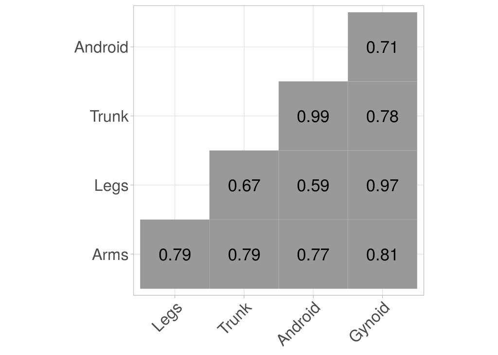

```r
ggcorrplot::ggcorrplot(COR_Beta, hc.order = F, type = "lower",
                       lab = TRUE, show.legend = F, lab_size = 6, tl.cex = 16,
                       ggtheme = ggplot2::theme_light(),
                       colors = c("gray60", "gray60", "gray60"))
```

# References

Ferrari, Silvia, and Francisco Cribari-Neto. 2004. “Beta Regression for Modelling Rates and Proportions.” *Journal of Applied Statistics* 31 (7): 799–815.

Kristensen, Kasper, Anders Nielsen, Casper W Berg, Hans Skaug, and Bradley M Bell. 2016. “TMB: Automatic Differentiation and Laplace Approximation.” *Journal of Statistical Software* 70 (5).

Petterle, Ricardo Rasmussen, Henrique Aparecido Laureano, Guilherme Parreira da Silva, and Wagner Hugo Bonat. 2021. “Multivariate Generalized Linear Mixed Models for Continuous Bounded Outcomes: Analyzing the Body Fat Percentage Data.” *Statistical Methods in Medical Research* (Accepted): 1–26.

Petterle, Ricardo R, Wagner H Bonat, Cassius T Scarpin, Thaı́sa Jonasson, and Victória ZC Borba. 2020. “Multivariate Quasi-Beta Regression Models for Continuous Bounded Data.” *The International Journal of Biostatistics* 1 (ahead-of-print).